# PPOL 670 | Assignment 04

Nick Stabile

9/22/2020

## DC Affordable Housing Investment Analysis FY15-19

**Data Source:** [DC FY19 Economic Development Return on Investment Data spreadsheet](https://dmped.dc.gov/sites/default/files/dc/sites/dmped/publication/attachments/Return%20on%20Investment%20Data_FY15-19_v3.xlsx)

**Data Author:** Office of the Deputy Mayor for Planning and Economic Development (DMPED)

**Github Repo:** [DSPP Assignment 04](https://github.com/ncstabile17/dspp-assignment04)

This data set pulls together economic development investments from across a variety of agencies and programs in the DC government for FY15-19. The data set was created by DMPED as required by the Economic Development Return on Investment Accountability Amendment Act of 2018. Fore more information see DMPED’s [FY19 Economic Development Return on Investment Accountability Report](https://dmped.dc.gov/sites/default/files/dc/sites/dmped/publication/attachments/FY19%20ED%20Return%20on%20Investment%20Accountability%20Report.pdf).

### Data Import and Cleaning

```r
# Making the variable names easier to work with
dc_housing_investment <- read_csv("data/dc-housing-investment.csv") %>%
  rename(
    year = `FY`,
    incentive_name = `Incentive Name`,
    recipient_name = `Recipient Name`,
    incentive_amount = `Incentive Amount`,
    investment_address = `MAR Address of Investment`,
    ward = `MAR_Ward`,
    ami_30 = `30% AMI`,
    ami_50 = `50% AMI`,
    ami_60 = `60% AMI`,
    ami_80 = `80% AMI`,
    total_affordable = `Total Affordable Units Produced or Preserved`,
    ) %>%
  # Ensuring variables are consistent and converting to numeric
  # Note that the "HFA Revenue Bond Issuance" was renamed to "HFA Revenue Bond" in 2019 so this code makes all years consistent
  mutate(
    investment_address = str_to_upper(investment_address),
    ami_30 = as.numeric(ami_30),
    ami_50 = as.numeric(ami_50),
    ami_60 = as.numeric(ami_60),
    ami_80 = as.numeric(ami_80),
    total_affordable = as.numeric(total_affordable),
    incentive_name=replace(incentive_name, incentive_name=="HFA Revenue Bond Issuance", "HFA Revenue Bond")
  )

# Some projects (denoted by address) had multiple investments from different programs so it's useful to know the total investment for each observation
# There is probably a more efficient way to add this variable
total_proj_data <- dc_housing_investment %>%
  group_by(investment_address) %>%
  summarize(total_proj_investment = sum(incentive_amount))

dc_housing_investment <-
  left_join(dc_housing_investment, total_proj_data, by = "investment_address")

# The set of ratio variables show how much a particular investment (observation) contributed to the overall project to account for projects with multiple investments
# The second set of variables was created to analyze the return on investment in terms of number of dollars invested for each unit
dc_housing_investment <- dc_housing_investment %>%
  mutate(
    investment_ratio = incentive_amount/total_proj_investment,
    total_affordable_ratio = investment_ratio*total_affordable,
    ami_30_ratio = investment_ratio*ami_30,
    ami_50_ratio = investment_ratio*ami_50,
    ami_60_ratio = investment_ratio*ami_60,
    ami_80_ratio = investment_ratio*ami_80,
    total_affordable_efficiency = if_else(total_affordable_ratio > 0, incentive_amount/total_affordable_ratio, 0),
    ami_30_efficiency = if_else(ami_30_ratio > 0, incentive_amount/ami_30_ratio, 0),
    ami_50_efficiency = if_else(ami_50_ratio > 0, incentive_amount/ami_50_ratio, 0),
    ami_60_efficiency = if_else(ami_60_ratio > 0, incentive_amount/ami_60_ratio, 0),
    ami_80_efficiency = if_else(ami_80_ratio > 0, incentive_amount/ami_80_ratio, 0),
    )

# Also probably a more efficient way to do this, but this removes any economic development incentives that did not produce any affordable housing units across the data set
min_affordable_units <- dc_housing_investment %>%
  group_by(incentive_name) %>%
  summarize(incentive_total_affordable = sum(total_affordable_ratio, na.rm = TRUE)) %>%
  filter(incentive_total_affordable > 0) %>%
  pull(incentive_name)

dc_housing_investment <- dc_housing_investment %>%
  filter(incentive_name %in% min_affordable_units)
```

### Figure 1. Production and Preservation of Affordable Units

Figure 1 shows the total number of affordable units produced or preserved for each program between FY15 and FY19. Combined, the issuance of bonds by the DC Housing Finance Agency and investments from the Housing Production Trust Fund make up the vast majority of affordable units produced or preserved during this time period. The Housing Preservation Fund is the only other program to top 1,000 units produced or preserved.

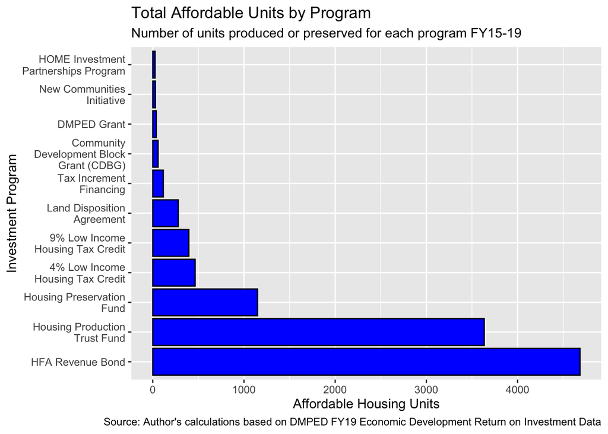

```r
dc_housing_investment %>%
  group_by(incentive_name) %>%
  summarize(incentive_total_affordable = sum(total_affordable_ratio, na.rm = TRUE)) %>%
  ggplot() +
  geom_col(mapping = aes(
    x = reorder(str_wrap(incentive_name, 20), -incentive_total_affordable),
    y = incentive_total_affordable),
    fill = "blue",
    color = "black") +
  labs(
    x = "Investment Program",
    y = "Affordable Housing Units",
    title = "Total Affordable Units by Program",
    subtitle = "Number of units produced or preserved for each program FY15-19",
    caption = "Source: Author's calculations based on DMPED FY19 Economic Development Return on Investment Data"
    ) +
  coord_flip()
```

### Figure 2.

Figure 2 shows the “efficiency” of investments in affordable housing by each program. The efficiency is shown as the average number of dollars spent per unit produced or preserved for each program. There is a visible difference between the efficiency of different programs, though no statistical tests were run to confirm the significance of these differences. The fill color shows the number of units produced or preserved as discussed in Figure 1, and we can see that there is no discernible relationship between the efficiency of the program and the number of units produced. Perhaps unsurprisingly, the Housing Preservation Fund is by far the most efficient program, though as its name implies it is focused on preserving already existing affordable units rather than producing new ones.

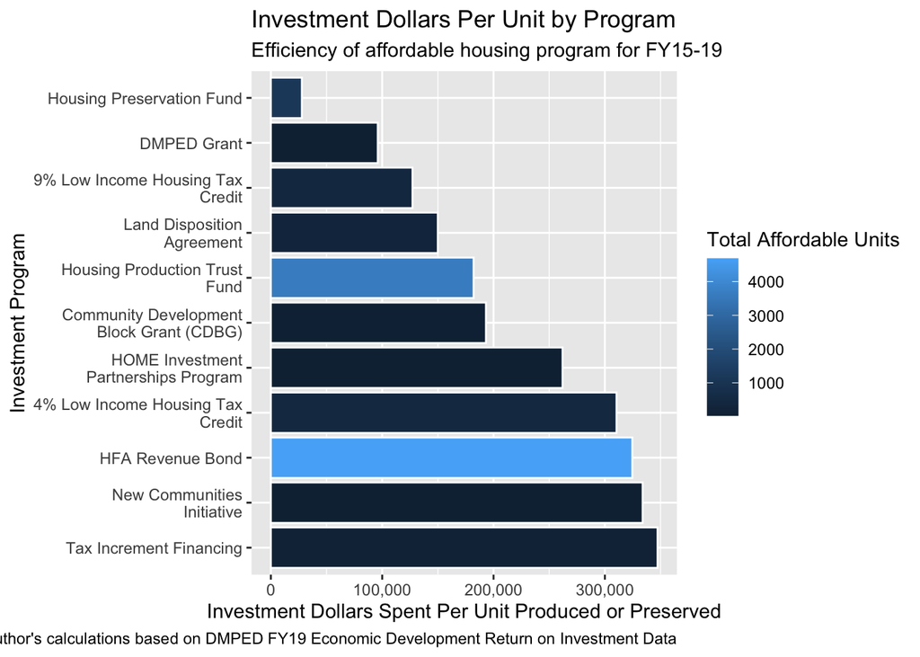

```r
dc_housing_investment %>%
  group_by(incentive_name) %>%
  summarize(incentive_total_affordable = sum(total_affordable_ratio, na.rm = TRUE),
            incentive_avg_efficiency = mean(total_affordable_efficiency, na.rm = TRUE)
            ) %>%
  ggplot() +
  geom_col(
    mapping = aes(
    x = reorder(str_wrap(incentive_name, 25), -incentive_avg_efficiency),
    y = incentive_avg_efficiency,
    fill = incentive_total_affordable),
    color = "white") +
  scale_y_continuous(labels = comma) +
  labs(
    x = "Investment Program",
    y = "Investment Dollars Spent Per Unit Produced or Preserved",
    fill = "Total Affordable Units",
    title = "Investment Dollars Per Unit by Program",
    subtitle = "Efficiency of affordable housing program for FY15-19",
    caption = "Source: Author's calculations based on DMPED FY19 Economic Development Return on Investment Data"
  ) +
  coord_flip()
```

### Figure 3. Investment in Affordable Housing Programs

As was to be expected based on the data presented in Figure 1, the total investments in affordable housing have been dominated by HFA bond issuance and Housing Production Trust Fund dollars from FY15-19. The investment over time is highly variable for most programs, with all but four having at least one year without any investment. On a positive note, the relatively new Housing Preservation Fund has preserved a large amount of units per dollar invested, demonstrating the strength of the program and providing support for its continued use and expansion in the coming years. We can also see the fairly large fluctuations in HFA bond investment from year to year. While the efficiency of this program was found to be comparatively low, further research would be needed to determine if other factors like type of unit and affordability level are playing a role in the differences in program efficiency.

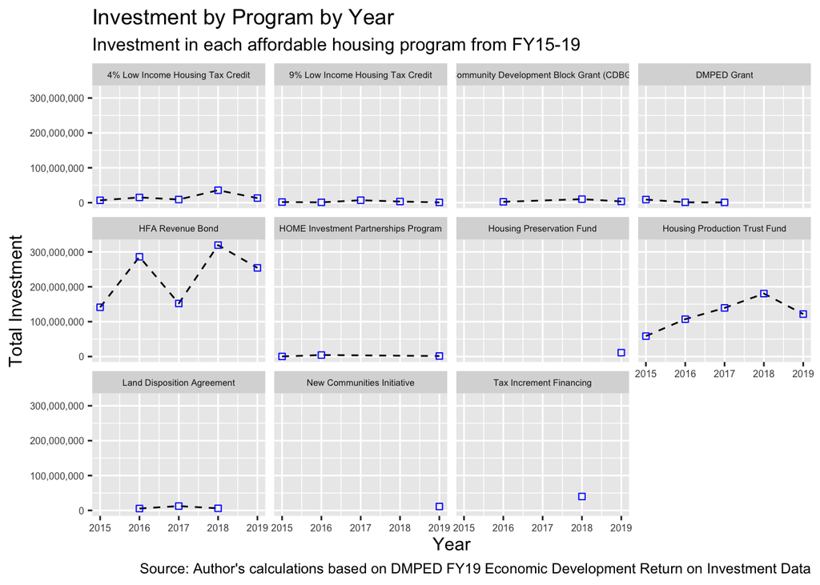

```r
dc_housing_investment %>%
  group_by(year, incentive_name) %>%
  summarize(incentive_total_year = sum(incentive_amount)) %>%
  ggplot() +
  geom_line(mapping = aes(
    x = year,
    y = incentive_total_year),
    linetype = "dashed") +
  geom_point(mapping = aes(
      x = year,
      y = incentive_total_year
    ),
    shape = 0, color = "blue") +
  scale_y_continuous(labels = comma) +
  facet_wrap(~ incentive_name) +
  theme(
    strip.text.x = element_text(size = 5.5),
    axis.text=element_text(size = 6)) +
  labs(
    x = "Year",
    y = "Total Investment",
    fill = "Year",
    title = "Investment by Program by Year",
    subtitle = "Investment in each affordable housing program from FY15-19",
    caption = "Source: Author's calculations based on DMPED FY19 Economic Development Return on Investment Data"
  )
```

### Figure 4. Affordable Housing Investment Across Wards

In Figure 4, we see the vastly uneven distribution of affordable housing investment by Ward. Wards 4, 7, and 8 have the largest concentration of developments with larger developments being particularly skewed towards Wards 7 and 8. While the strong investment in Wards 7 and 8 is crucial for providing adequate affordability for lower income populations that are concentrated in these Wards, the lack of affordable housing development in Wards 2 and 3 further concentrates poverty and makes it difficult for lower income people to live in these more prosperous Wards. Making adequate investments in affordable housing in all Wards will be crucial for meeting the affordable housing distribution goals set out in the [Mayor’s Housing Equity Report](https://housing.dc.gov/sites/default/files/dc/sites/housingdc/page_content/attachments/Housing%20Equity%20Report%2010-15-19.pdf). Affordable housing investment by Ward seems to be fairly consistent across years in this data set.

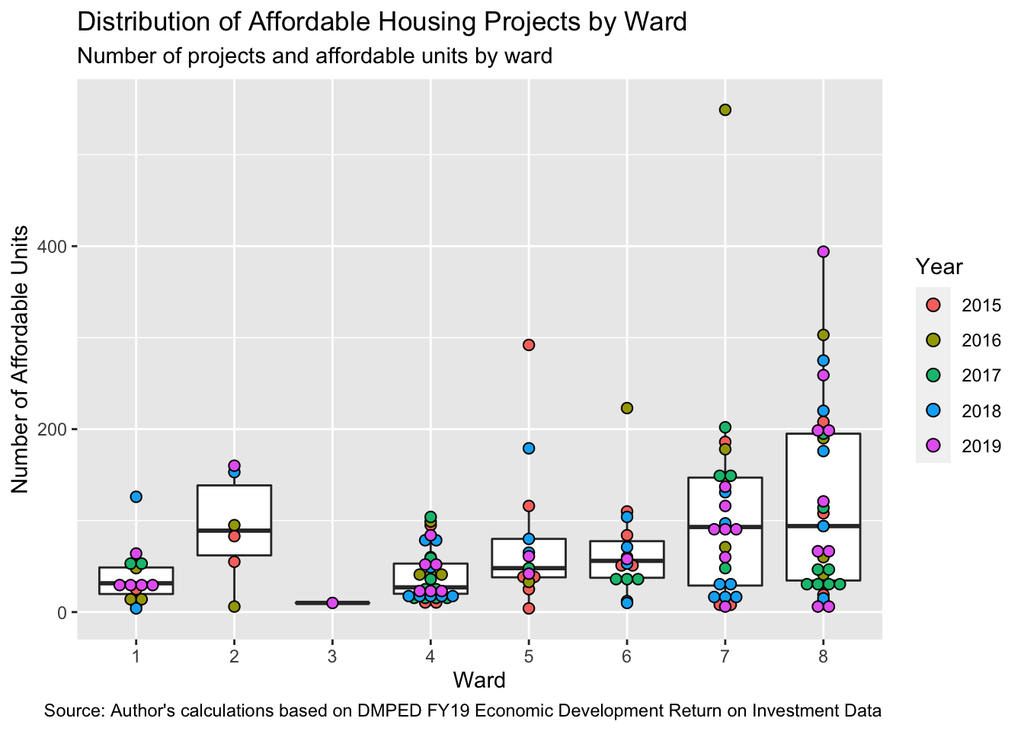

```r
dc_housing_investment %>%
  distinct(investment_address, .keep_all = TRUE) %>%
  filter(!is.na(ward)) %>%
  ggplot() +
  geom_boxplot(mapping = aes(
    x = ward,
    y = total_affordable)) +
  geom_dotplot(mapping = aes(
    x = ward,
    y = total_affordable,
    fill = as.factor(year),
    ),
    binaxis='y',
    stackdir='center',
    binwidth = 12) +
  scale_x_discrete(
    labels = c("Ward 1" = "1",
               "Ward 2" = "2",
               "Ward 3" = "3",
               "Ward 4" = "4",
               "Ward 5" = "5",
               "Ward 6" = "6",
               "Ward 7" = "7",
               "Ward 8" = "8")
  ) +
  labs(
    x = "Ward",
    y = "Number of Affordable Units",
    fill = "Year",
    title = "Distribution of Affordable Housing Projects by Ward",
    subtitle = "Number of projects and affordable units by ward",
    caption = "Source: Author's calculations based on DMPED FY19 Economic Development Return on Investment Data"
  )
```

### Figure 5. Using Programs in Combination

While the majority of affordable housing developments received money from only one program in this data set, many received funding from 2 or 3 sources. This is an area that could be explored in future analyses to determine if there is any meaningful difference between developments that receive funding from a different number of sources. There could also be additional research into whether particular programs work well paired together or if the efficiency of the return on investment changes depending on the particular combination of funding sources. It may also be useful to explore the outlier projects that received funding from 4 or more sources.

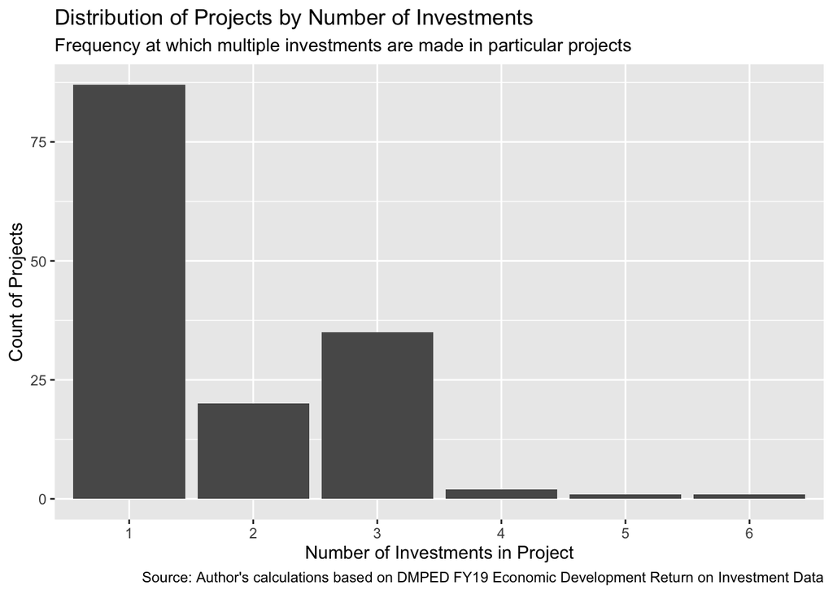

```r
dc_housing_investment %>%
  count(investment_address) %>%
  ggplot() +
  geom_bar(aes(x = n)) +
  scale_x_discrete(
    limit = c("1" = "1",
               "2" = "2",
               "3" = "3",
               "4" = "4",
               "5" = "5",
               "6" = "6")
  ) +
  labs(
    x = "Number of Investments in Project",
    y = "Count of Projects",
    title = "Distribution of Projects by Number of Investments",
    subtitle = "Frequency at which multiple investments are made in particular projects",
    caption = "Source: Author's calculations based on DMPED FY19 Economic Development Return on Investment Data"
  )
```